# QIMR_CNV_profiling

### Visualizing the copyKAT predictions to identify tumor region

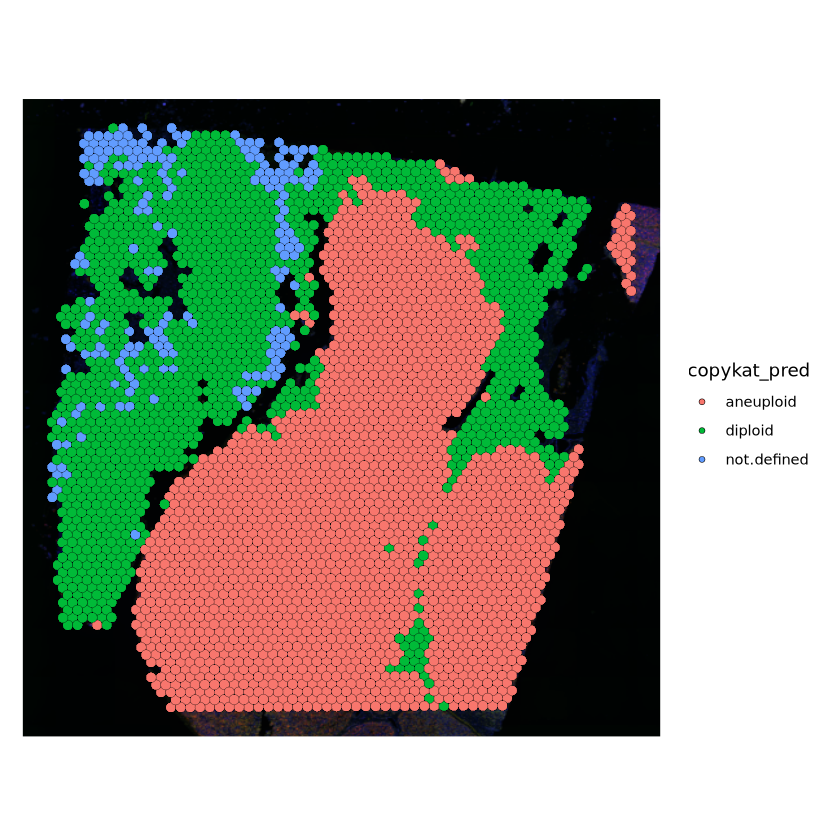

```python
p<-read.csv("test_copykat_prediction.txt", sep="\t",header=TRUE)
colnames(spatial_data)<-gsub("-1",".1",colnames(spatial_data))
spatial_data_sub<-subset(spatial_data, cells = p$cell.names)

seurat_colnames<-colnames(spatial_data_sub)
rownames(p)<-p$cell.names
p<-p[seurat_colnames,]

# Find the order of the BC values in the seurat_colnames
bc_order <- match(p$cell.names, seurat_colnames)

# Reorder the columns of infercnv_sub_groupings based on the order
p_reordered <- p[order(bc_order), ]

spatial_data_sub@meta.data$copykat_pred<-p$copykat.pred
SpatialDimPlot(spatial_data_sub, group.by = "copykat_pred")
```

### Adding subclone information to the spatial object and visualizing subclones

```python
c<-read.csv("3subclones_BCs.csv")
dim(c)
head(c)
```

1. 1912

2. 1

A data.frame: 6 × 1

|  | x <int> |
| --- | --- |
| AACACTTGGCAAGGAA.1 | 1 |
| AACAGGATTCATAGTT.1 | 1 |
| AACAGGTTCACCGAAG.1 | 1 |
| AACATAGTCTATCTAC.1 | 2 |
| AACATCTAATGACCGG.1 | 1 |
| AACATGCGCAAGTGAG.1 | 2 |

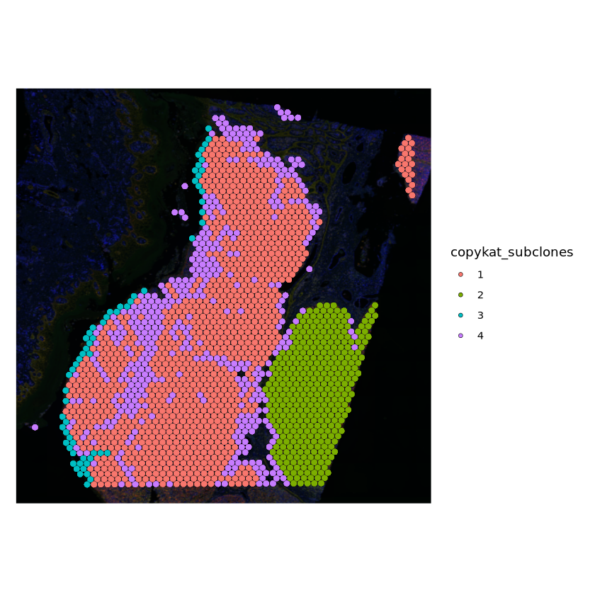

```python
spatial_data_subclones<-subset(spatial_data_sub, cells = rownames(c))

seurat_colnames<-colnames(spatial_data_subclones)

# Find the order of the BC values in the seurat_colnames
bc_order <- match(rownames(c), seurat_colnames)

# Reorder the columns of infercnv_sub_groupings based on the order
c_reordered <- c[order(bc_order), ]
spatial_data_subclones@meta.data$copykat_subclones <- c$x
SpatialDimPlot(spatial_data_subclones, group.by = "copykat_subclones")
```

### Save the processed data for further analysis

```python
saveRDS(spatial_data,"spatial_data.rds")
saveRDS(spatial_data_subclones,"spatial_data_subclones.rds")
```

# SUMMARY

Both of the discussed tools can be applied to scRNA-seq and spatial transcriptomics data

- CopyKAT
  - Cell-type annotation free tool to identify aneuploid (Tumor cells)
  - To infer subclones of tumor
  - Time consuming but easy to interpret
- InferCNV
  - Mainly to predict CNV profiles of annotated tumor cells by comparing with the annotated normal cells and to identify subclones.
  - Can also predict tumor cells when cell-type annotations are unknown
  - Quick to run but not as easy as CopyKAT to interpret results

Other new tools to explore: 'SCEVAN' (https://www.nature.com/articles/s41467-023-36790-9)